# steps to clean and apply a ML model on the Titanic dataset

1. Load the Titanic dataset.
2. Raw data inspection and understanding.
3. Data Quality Checks.
4. Statistical Summary and Visualization.
5. Data Cleaning (Handling Missing Values, Outliers, Duplicates).
6. Feature Engineering (Creating new features, Encoding categorical variables).
7. Data Normalization/Standardization.
8. ML readiness (Splitting data into training and testing sets).
9. Model Selection and Training.
1. Problem Statement & Goal
2. Load Titanic Dataset
3. Initial Data Inspection
4. Data Quality Report
5. Univariate EDA
6. Bivariate EDA
7. Statistical Measures (IQR, Skewness, Kurtosis)
8. Outlier Detection & Treatment
9. Missing Value Strategy
10. Feature Engineering
11. Encoding & Scaling
12. Train-Test Split
13. Baseline ML Model
14. Improved ML Model
15. Final Evaluation & Learnings

## Raw Data Inspection and Understanding

- Load the dataset using pandas.
- shape,columns,datatypes,info,describe,head,tail
- first loook at rows

```python
import pandas as pd
import numpy as np
import seaborn as sns
```

```python
df = sns.load_dataset('titanic')
```

```python
df.head()
```

|  | survived | pclass | sex | age | sibsp | parch | fare | embarked | class | who | adult_male | deck | embark_town | alive | alone |
| --- | --- | --- | --- | --- | --- | --- | --- | --- | --- | --- | --- | --- | --- | --- | --- |
| 0 | 0 | 3 | male | 22.0 | 1 | 0 | 7.2500 | S | Third | man | True | NaN | Southampton | no | False |
| 1 | 1 | 1 | female | 38.0 | 1 | 0 | 71.2833 | C | First | woman | False | C | Cherbourg | yes | False |
| 2 | 1 | 3 | female | 26.0 | 0 | 0 | 7.9250 | S | Third | woman | False | NaN | Southampton | yes | True |
| 3 | 1 | 1 | female | 35.0 | 1 | 0 | 53.1000 | S | First | woman | False | C | Southampton | yes | False |
| 4 | 0 | 3 | male | 35.0 | 0 | 0 | 8.0500 | S | Third | man | True | NaN | Southampton | no | True |

```python
df.shape
```

```
(891, 15)
```

```python
df.columns
```

```
Index(['survived', 'pclass', 'sex', 'age', 'sibsp', 'parch', 'fare',
       'embarked', 'class', 'who', 'adult_male', 'deck', 'embark_town',
       'alive', 'alone'],
      dtype='object')
```

```python
df.info()
```

```
<class 'pandas.core.frame.DataFrame'>
RangeIndex: 891 entries, 0 to 890
Data columns (total 15 columns):
 #   Column       Non-Null Count  Dtype
---  ------       --------------  -----
 0   survived     891 non-null    int64
 1   pclass       891 non-null    int64
 2   sex          891 non-null    object
 3   age          714 non-null    float64
 4   sibsp        891 non-null    int64
 5   parch        891 non-null    int64
 6   fare         891 non-null    float64
 7   embarked     889 non-null    object
 8   class        891 non-null    category
 9   who          891 non-null    object
 10  adult_male   891 non-null    bool
 11  deck         203 non-null    category
 12  embark_town  889 non-null    object
 13  alive        891 non-null    object
 14  alone        891 non-null    bool
dtypes: bool(2), category(2), float64(2), int64(4), object(5)
memory usage: 80.7+ KB
```

```python
df.describe()
```

|  | survived | pclass | age | sibsp | parch | fare |
| --- | --- | --- | --- | --- | --- | --- |
| count | 891.000000 | 891.000000 | 714.000000 | 891.000000 | 891.000000 | 891.000000 |
| mean | 0.383838 | 2.308642 | 29.699118 | 0.523008 | 0.381594 | 32.204208 |
| std | 0.486592 | 0.836071 | 14.526497 | 1.102743 | 0.806057 | 49.693429 |
| min | 0.000000 | 1.000000 | 0.420000 | 0.000000 | 0.000000 | 0.000000 |
| 25% | 0.000000 | 2.000000 | 20.125000 | 0.000000 | 0.000000 | 7.910400 |
| 50% | 0.000000 | 3.000000 | 28.000000 | 0.000000 | 0.000000 | 14.454200 |
| 75% | 1.000000 | 3.000000 | 38.000000 | 1.000000 | 0.000000 | 31.000000 |
| max | 1.000000 | 3.000000 | 80.000000 | 8.000000 | 6.000000 | 512.329200 |

## Data Quality Checks

- Check for missing values.
- Check for duplicates.
- Check for inconsistent data types.
- invvalid values

```python
df.isnull().sum()
```

```
survived         0
pclass           0
sex              0
age            177
sibsp            0
parch            0
fare             0
embarked         2
class            0
who              0
adult_male       0
deck           688
embark_town      2
alive            0
alone            0
dtype: int64
```

```python
missing_pct = df.isnull().mean() * 100
missing_pct.sort_values(ascending=False)
```

```
deck           77.216611
age            19.865320
embarked        0.224467
embark_town     0.224467
sex             0.000000
pclass          0.000000
survived        0.000000
fare            0.000000
parch           0.000000
sibsp           0.000000
class           0.000000
adult_male      0.000000
who             0.000000
alive           0.000000
alone           0.000000
dtype: float64
```

```python
df.duplicated().sum()
```

```
np.int64(107)
```

```python
for col in df.select_dtypes(include="object"):
    print(f"{col}: {df[col].nunique()} unique values")
```

```
sex: 2 unique values
embarked: 3 unique values
who: 3 unique values
embark_town: 3 unique values
alive: 2 unique values
```

```python
df.describe(include="all")
```

|  | survived | pclass | sex | age | sibsp | parch | fare | embarked | class | who | adult_male | deck | embark_town | alive | alone |
| --- | --- | --- | --- | --- | --- | --- | --- | --- | --- | --- | --- | --- | --- | --- | --- |
| count | 891.000000 | 891.000000 | 891 | 714.000000 | 891.000000 | 891.000000 | 891.000000 | 889 | 891 | 891 | 891 | 203 | 889 | 891 | 891 |
| unique | NaN | NaN | 2 | NaN | NaN | NaN | NaN | 3 | 3 | 3 | 2 | 7 | 3 | 2 | 2 |
| top | NaN | NaN | male | NaN | NaN | NaN | NaN | S | Third | man | True | C | Southampton | no | True |
| freq | NaN | NaN | 577 | NaN | NaN | NaN | NaN | 644 | 491 | 537 | 537 | 59 | 644 | 549 | 537 |
| mean | 0.383838 | 2.308642 | NaN | 29.699118 | 0.523008 | 0.381594 | 32.204208 | NaN | NaN | NaN | NaN | NaN | NaN | NaN | NaN |
| std | 0.486592 | 0.836071 | NaN | 14.526497 | 1.102743 | 0.806057 | 49.693429 | NaN | NaN | NaN | NaN | NaN | NaN | NaN | NaN |
| min | 0.000000 | 1.000000 | NaN | 0.420000 | 0.000000 | 0.000000 | 0.000000 | NaN | NaN | NaN | NaN | NaN | NaN | NaN | NaN |
| 25% | 0.000000 | 2.000000 | NaN | 20.125000 | 0.000000 | 0.000000 | 7.910400 | NaN | NaN | NaN | NaN | NaN | NaN | NaN | NaN |
| 50% | 0.000000 | 3.000000 | NaN | 28.000000 | 0.000000 | 0.000000 | 14.454200 | NaN | NaN | NaN | NaN | NaN | NaN | NaN | NaN |
| 75% | 1.000000 | 3.000000 | NaN | 38.000000 | 1.000000 | 0.000000 | 31.000000 | NaN | NaN | NaN | NaN | NaN | NaN | NaN | NaN |
| max | 1.000000 | 3.000000 | NaN | 80.000000 | 8.000000 | 6.000000 | 512.329200 | NaN | NaN | NaN | NaN | NaN | NaN | NaN | NaN |

🧠 Data Quality Summary (write this in markdown)

In your notebook, add a markdown cell like:

Data Quality Findings

Missing values in age, deck, embark_town

Deck has excessive missing data

Fare appears heavily skewed

Target leakage column present (alive)

## Exploratory Data Analysis (EDA)

- univariate analysis
- Bivariate analysis
- Multivariate analysis
- correlation analysis
- Distribution of numerical features

```python
import matplotlib.pyplot as plt
import seaborn as sns

sns.set_style("whitegrid")
```

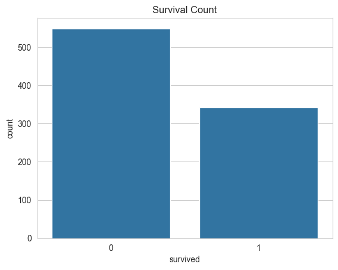

```python
# analysis target
sns.countplot(x='survived', data=df)
plt.title('Survival Count')
plt.show()
```

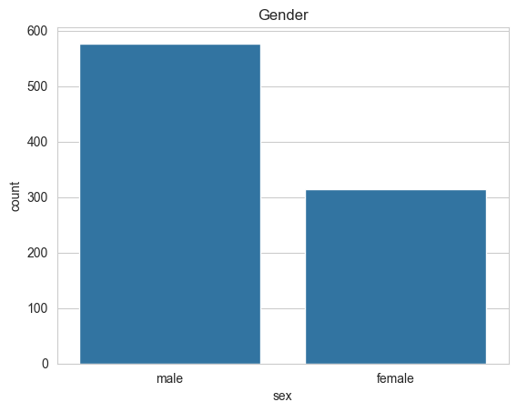

```python
sns.countplot(x='sex',data=df)
plt.title('Gender')
plt.show()
```

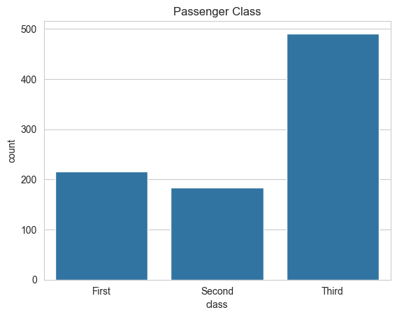

```python
sns.countplot(x='class',data=df)
plt.title('Passenger Class')
plt.show()
```

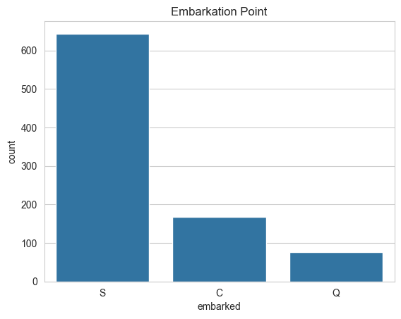

```python
sns.countplot(x='embarked',data=df)
plt.title('Embarkation Point')
plt.show()
```

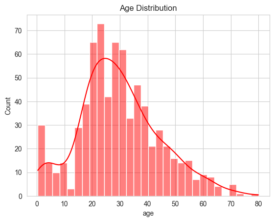

```python
sns.histplot(df['age'].dropna(), bins=30, kde=True, color='red')
plt.title('Age Distribution')
plt.show()
```

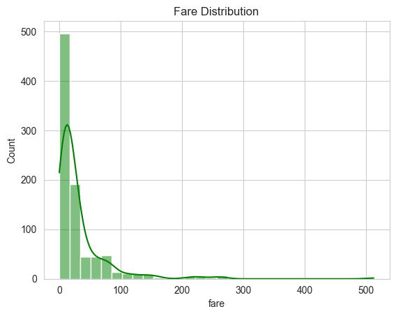

```python
sns.histplot(df['fare'], bins=30, kde=True, color='green')
plt.title('Fare Distribution')
plt.show()
```

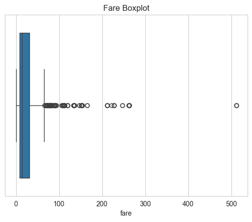

```python
sns.boxplot(x=df['fare'])
plt.title('Fare Boxplot')
plt.show()
```

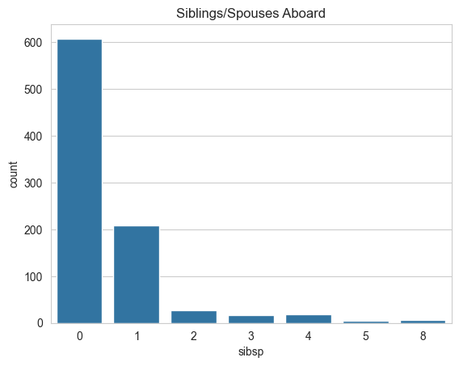

```python
sns.countplot(x='sibsp',data=df)
plt.title('Siblings/Spouses Aboard')
plt.show()
```

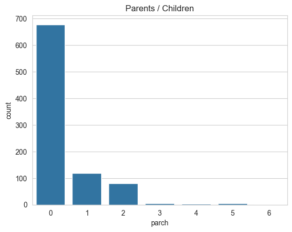

```python
sns.countplot(x="parch", data=df)
plt.title("Parents / Children")
plt.show()
```

🧠 What you learned in Step 4

✔ Dataset imbalance ✔ Which features are skewed ✔ Which features are categorical vs numeric ✔ Where outliers probably exist ✔ Which features need transformation later

## Bivariate Analysis

- Relationships between features and target variable (survived)

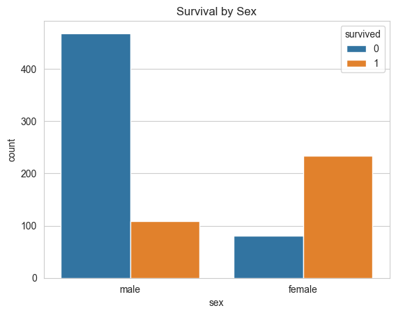

```python
sns.countplot(x="sex", hue="survived", data=df)
plt.title("Survival by Sex")
plt.show()
```

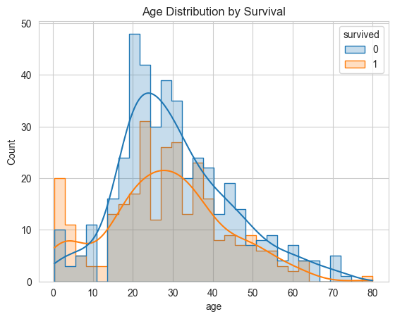

```python
sns.histplot(data=df,x='age',hue='survived',bins=30,kde=True,element='step')

plt.title("Age Distribution by Survival")
plt.show()
```

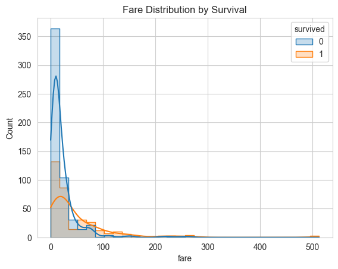

```python
sns.histplot(
    data=df,
    x= "fare",
    hue="survived",
    bins=30,
    kde=True,
    element="step"
)

plt.title("Fare Distribution by Survival")
plt.show()
```

```python
df["family_size"] = df["sibsp"] + df["parch"] + 1
```

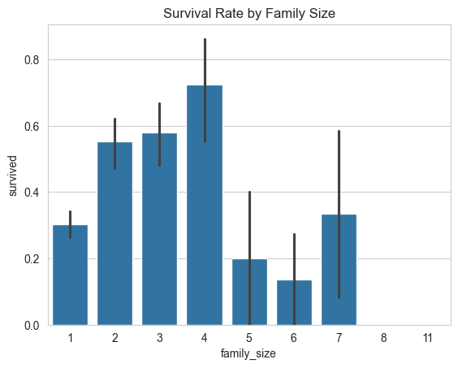

```python
sns.barplot(x='family_size', y='survived', data=df)
plt.title('Survival Rate by Family Size')
plt.show()
```

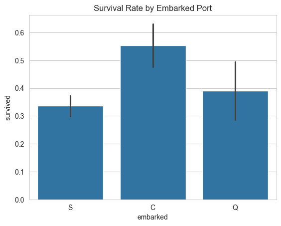

```python
sns.barplot(x="embarked", y="survived", data=df)
plt.title("Survival Rate by Embarked Port")
plt.show()
```

## Multivariate Analysis

- Correlation heatmap

```python
num_df = df.select_dtypes(include=["int64", "float64"])
```

```python
corr = num_df.corr()
corr
```

|  | survived | pclass | age | sibsp | parch | fare | family_size |
| --- | --- | --- | --- | --- | --- | --- | --- |
| survived | 1.000000 | -0.338481 | -0.077221 | -0.035322 | 0.081629 | 0.257307 | 0.016639 |
| pclass | -0.338481 | 1.000000 | -0.369226 | 0.083081 | 0.018443 | -0.549500 | 0.065997 |
| age | -0.077221 | -0.369226 | 1.000000 | -0.308247 | -0.189119 | 0.096067 | -0.301914 |
| sibsp | -0.035322 | 0.083081 | -0.308247 | 1.000000 | 0.414838 | 0.159651 | 0.890712 |
| parch | 0.081629 | 0.018443 | -0.189119 | 0.414838 | 1.000000 | 0.216225 | 0.783111 |
| fare | 0.257307 | -0.549500 | 0.096067 | 0.159651 | 0.216225 | 1.000000 | 0.217138 |
| family_size | 0.016639 | 0.065997 | -0.301914 | 0.890712 | 0.783111 | 0.217138 | 1.000000 |

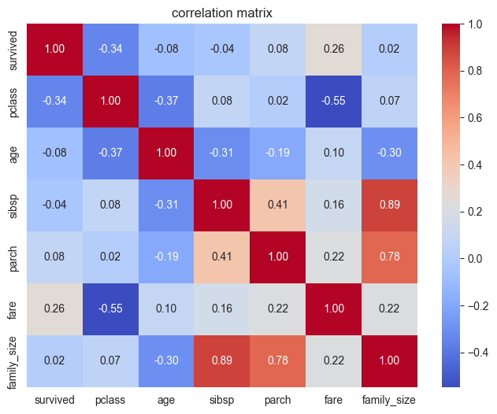

```python
## 0.7 > strng corelation

plt.figure(figsize=(8,6))
sns.heatmap(corr,annot=True,cmap="coolwarm", fmt='.2f')
plt.title("correlation matrix")
plt.show()
```

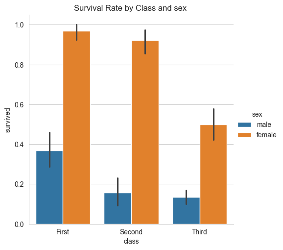

```python
sns.catplot(
    x='class',
    y='survived',
    data=df,
    hue='sex',
    kind='bar',
    height=5
)
plt.title("Survival Rate by Class and sex ")
plt.show()
```

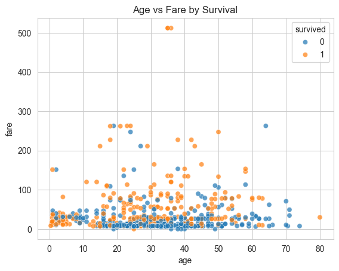

```python
sns.scatterplot(x="age",y="fare",hue="survived",data=df,alpha=0.7)
plt.title("Age vs Fare by Survival")
plt.show()
```

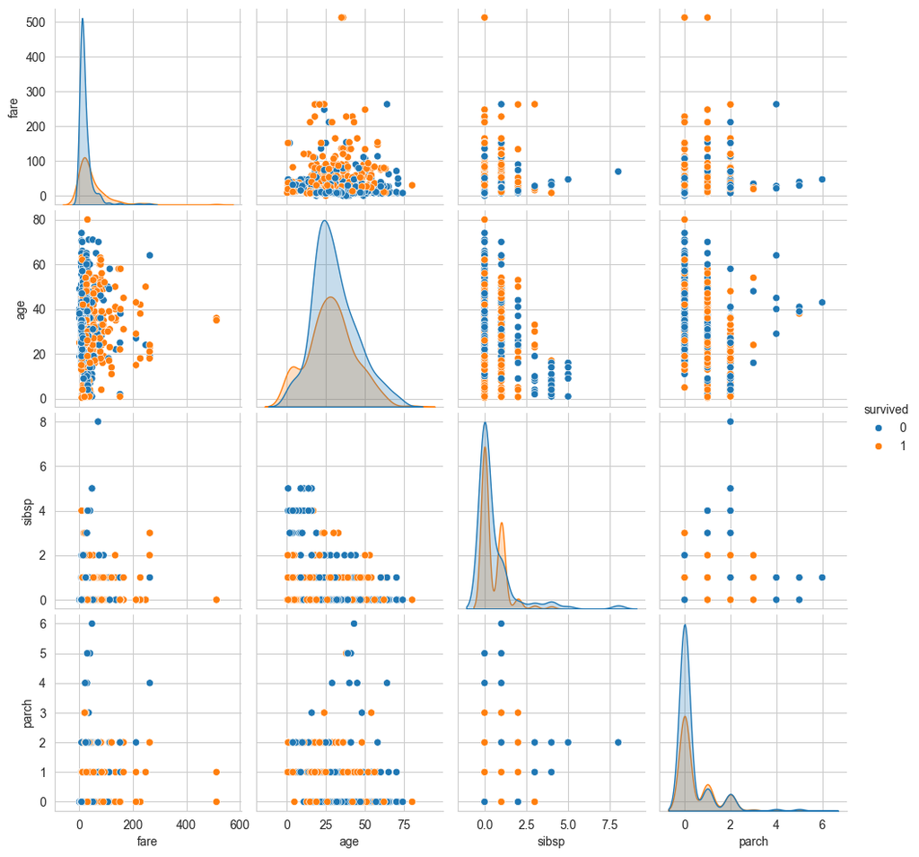

```python
sns.pairplot(df[["survived","fare","age","sibsp","parch"]],hue="survived")
plt.show()
```

🧠 What Step 6 gives you

✔ Which features interact ✔ Which ones carry similar information ✔ Which features deserve engineering ✔ Which models may work better

## Statistical understanding of data

- Central Tendency (Mean, Median, Mode)
- Dispersion (Range, Variance, Standard Deviation)
- IQR (Interquartile Range)
- Skewness and Kurtosis
- Visualizations (Histograms, Box Plots, Scatter Plots)
- interpretation of statistical measures

```python
num_df = df.select_dtypes(include=["int64", "float64"])
num_df.columns
```

```
Index(['survived', 'pclass', 'age', 'sibsp', 'parch', 'fare', 'family_size'], dtype='object')
```

```python
num_df.mean()
```

```
survived        0.383838
pclass          2.308642
age            29.699118
sibsp           0.523008
parch           0.381594
fare           32.204208
family_size     1.904602
dtype: float64
```

```python
num_df.median()
```

```
survived        0.0000
pclass          3.0000
age            28.0000
sibsp           0.0000
parch           0.0000
fare           14.4542
family_size     1.0000
dtype: float64
```

```python
num_df.mode()
```

|  | survived | pclass | age | sibsp | parch | fare | family_size |
| --- | --- | --- | --- | --- | --- | --- | --- |
| 0 | 0 | 3 | 24.0 | 0 | 0 | 8.05 | 1 |

```python
num_df[["age","fare"]].median()
```

```
age     28.0000
fare    14.4542
dtype: float64
```

```python
num_df.std()
```

```
survived        0.486592
pclass          0.836071
age            14.526497
sibsp           1.102743
parch           0.806057
fare           49.693429
family_size     1.613459
dtype: float64
```

```python
# interpretation rule for skewness
# - A skewness value > 1 or < -1 indicates a highly skewed distribution.
# - A skewness value between 0.5 and 1 or between -0.5 and -1 indicates a moderately skewed distribution.
# - A skewness value between -0.5 and 0.5 indicates a approximately symmetric distribution.

num_df.skew()
```

```
survived       0.478523
pclass        -0.630548
age            0.389108
sibsp          3.695352
parch          2.749117
fare           4.787317
family_size    2.727441
dtype: float64
```

```python
# higher the kurtosis value, the heavier the tails of the distribution.
# high kurtosis indicates more outliers.
# lower/negative kurtosis indicates lighter tails.

num_df.kurtosis()
```

```
survived       -1.775005
pclass         -1.280015
age             0.178274
sibsp          17.880420
parch           9.778125
fare           33.398141
family_size     9.159666
dtype: float64
```

```python
Q1 = num_df.quantile(0.25)
Q3 = num_df.quantile(0.75)
IQR = Q3 - Q1

lower_bound = Q1 - 1.5 * IQR
upper_bound = Q3 + 1.5 * IQR

lower_bound ,    upper_bound
```

```
(survived       -1.5000
 pclass          0.5000
 age            -6.6875
 sibsp          -1.5000
 parch           0.0000
 fare          -26.7240
 family_size    -0.5000
 dtype: float64,
 survived        2.5000
 pclass          4.5000
 age            64.8125
 sibsp           2.5000
 parch           0.0000
 fare           65.6344
 family_size     3.5000
 dtype: float64)
```

```python
outliers = num_df[(num_df < lower_bound) | (num_df > upper_bound)]

outliers.shape
```

```
(891, 7)
```

Statistical conclusions (WRITE THIS)

Add a markdown cell:

Statistical Findings

Fare is highly right-skewed with high kurtosis

Fare contains many extreme outliers

Age is mildly skewed with missing values

Mean is unreliable for fare → use median / robust methods

Our options (decision table) Method When to use Remove Measurement error Cap (Winsorize) Extreme but valid Transform Skewed distributions Keep Tree models

For Titanic fare → Transform + Robust Scaling

## Data Cleaning

- Handling Missing Values
- Outliers treatment
- Fixing Skewness
- Duplicates Removal
- removing leakage & useless features

```python
df_clean = df.copy()
```

```python
Q1 = df_clean["fare"].quantile(0.25)
Q3 = df_clean["fare"].quantile(0.75)
IQR = Q3 - Q1


lower = Q1 - 1.5*IQR
upper = Q3 + 1.5*IQR
```

```python
df_clean["fare_capped"] = df_clean["fare"].clip(lower, upper)
```

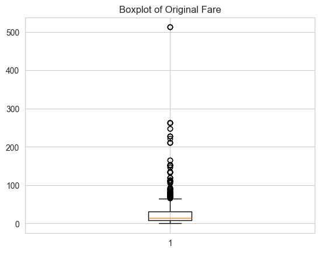

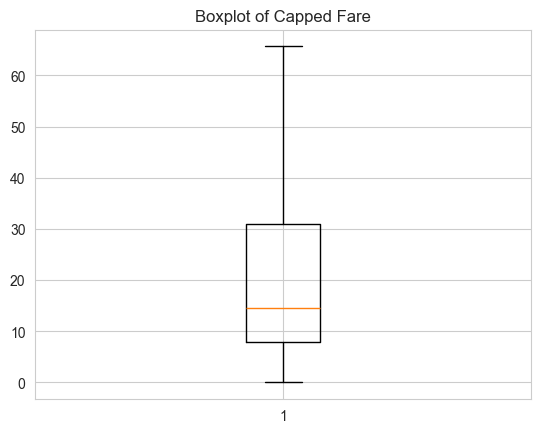

```python
plt.boxplot(df["fare"].dropna())
plt.title("Boxplot of Original Fare")
plt.show()

plt.boxplot(df_clean["fare_capped"].dropna())
plt.title("Boxplot of Capped Fare")
plt.show()
```

```python
# Log Transformation
df_clean["fare_log"] = np.log1p(df_clean["fare"])
```

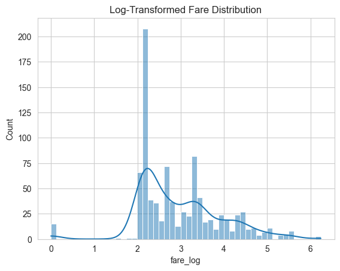

```python
sns.histplot(data=df_clean["fare_log"], bins= 50 , kde=True)
plt.title("Log-Transformed Fare Distribution")
plt.show()
```

🧠 What you learned in Step 8

✔ Outliers ≠ bad data ✔ Capping > removing for real-world data ✔ Transformation beats deletion ✔ Cleaning depends on the model you plan to use

```python
## Missing value tratment

df_clean.isnull().sum()
```

```
survived         0
pclass           0
sex              0
age            177
sibsp            0
parch            0
fare             0
embarked         2
class            0
who              0
adult_male       0
deck           688
embark_town      2
alive            0
alone            0
family_size      0
fare_capped      0
fare_log         0
dtype: int64
```

```python
# decide drop vs impite(key logic )
# deck highly missing adds noise
# drop

df_clean.drop(columns="deck", inplace=True)
```

```python
# embark_town
# similar to embarked same info different format

df_clean.drop(columns="embark_town", inplace=True)
```

```python
# check most frequent values

df_clean['embarked'].value_counts()
```

```
embarked
S    644
C    168
Q     77
Name: count, dtype: int64
```

```python
# fill na value with mode values that is "S"

df_clean["embarked"].fillna("S", inplace=True)
```

```python
df_clean["age"].median()
```

```
np.float64(28.0)
```

```python
# fill the nan valus of age with the median  of the age column

df_clean["age"].fillna(df_clean["age"].median(), inplace=True)
```

```python
df_clean.isnull().sum()
```

```
survived       0
pclass         0
sex            0
age            0
sibsp          0
parch          0
fare           0
embarked       0
class          0
who            0
adult_male     0
alive          0
alone          0
family_size    0
fare_capped    0
fare_log       0
dtype: int64
```

## Feature Engineering

- Creating new features
- Encoding categorical variables
- scaling features if necessary
- normalization/standardization
- Dimensionality Reduction if needed
- feature selection techniques

```python
df_clean["family_size"] = df_clean["sibsp"] + df_clean["parch"]+1
```

```python
# is_alone is basically family_size 1

df_clean["is_alone"] = (df_clean["family_size"] == 1).astype(int)
```

```python
# title extraction from name (safe: handle datasets without 'name' column)
if 'name' in df_clean.columns:
	df_clean["title"] = df_clean["name"].str.extract(r" ([A-Za-z]+)\.", expand=False)
else:
	def _derive_title(row):
		if row.get('sex') == 'male':
			return 'Mr'
		if row.get('sex') == 'female':
			age = row.get('age')
			try:
				if pd.notnull(age) and age < 18:
					return 'Miss'
			except Exception:
				pass
			return 'Mrs'
		return 'Unknown'
	df_clean["title"] = df_clean.apply(_derive_title, axis=1)
```

```python
df_clean
```

|  | survived | pclass | sex | age | sibsp | parch | fare | embarked | class | who | adult_male | alive | alone | family_size | fare_capped | fare_log | is_alone | title |
| --- | --- | --- | --- | --- | --- | --- | --- | --- | --- | --- | --- | --- | --- | --- | --- | --- | --- | --- |
| 0 | 0 | 3 | male | 22.0 | 1 | 0 | 7.2500 | S | Third | man | True | no | False | 2 | 7.2500 | 2.110213 | 0 | Mr |
| 1 | 1 | 1 | female | 38.0 | 1 | 0 | 71.2833 | C | First | woman | False | yes | False | 2 | 65.6344 | 4.280593 | 0 | Mrs |
| 2 | 1 | 3 | female | 26.0 | 0 | 0 | 7.9250 | S | Third | woman | False | yes | True | 1 | 7.9250 | 2.188856 | 1 | Mrs |
| 3 | 1 | 1 | female | 35.0 | 1 | 0 | 53.1000 | S | First | woman | False | yes | False | 2 | 53.1000 | 3.990834 | 0 | Mrs |
| 4 | 0 | 3 | male | 35.0 | 0 | 0 | 8.0500 | S | Third | man | True | no | True | 1 | 8.0500 | 2.202765 | 1 | Mr |
| ... | ... | ... | ... | ... | ... | ... | ... | ... | ... | ... | ... | ... | ... | ... | ... | ... | ... | ... |
| 886 | 0 | 2 | male | 27.0 | 0 | 0 | 13.0000 | S | Second | man | True | no | True | 1 | 13.0000 | 2.639057 | 1 | Mr |
| 887 | 1 | 1 | female | 19.0 | 0 | 0 | 30.0000 | S | First | woman | False | yes | True | 1 | 30.0000 | 3.433987 | 1 | Mrs |
| 888 | 0 | 3 | female | 28.0 | 1 | 2 | 23.4500 | S | Third | woman | False | no | False | 4 | 23.4500 | 3.196630 | 0 | Mrs |
| 889 | 1 | 1 | male | 26.0 | 0 | 0 | 30.0000 | C | First | man | True | yes | True | 1 | 30.0000 | 3.433987 | 1 | Mr |
| 890 | 0 | 3 | male | 32.0 | 0 | 0 | 7.7500 | Q | Third | man | True | no | True | 1 | 7.7500 | 2.169054 | 1 | Mr |

891 rows × 18 columns

```python
# we dived the passangers on the basess of their rang and gender

df_clean["titles"] = df_clean["title"].replace(["Lady", "Countess", "Capt", "Col", "Don", "Dr",
     "Major", "Rev", "Sir", "Jonkheer", "Dona"],
    "Rare"
    )

df_clean["title"] = df_clean["title"].replace(["Mlle","Ms"],"Miss")

df_clean["title"]= df_clean["title"].replace("Mme","Mrs")
```

```python
df_clean["title"].value_counts()
```

```
title
Mr      577
Mrs     259
Miss     55
Name: count, dtype: int64
```

```python
## group the people will help us most of the  times

df_clean["age_group"] = pd.cut(
    df_clean["age"],
    bins=[0, 12, 20, 35, 60, 80],
    labels=["Child", "Teenager", "Young Adult", "Adult", "Senior"]
)
```

```python
df_clean
```

|  | survived | pclass | sex | age | sibsp | parch | fare | embarked | class | who | adult_male | alive | alone | family_size | fare_capped | fare_log | is_alone | title | titles | age_group |
| --- | --- | --- | --- | --- | --- | --- | --- | --- | --- | --- | --- | --- | --- | --- | --- | --- | --- | --- | --- | --- |
| 0 | 0 | 3 | male | 22.0 | 1 | 0 | 7.2500 | S | Third | man | True | no | False | 2 | 7.2500 | 2.110213 | 0 | Mr | Mr | Young Adult |
| 1 | 1 | 1 | female | 38.0 | 1 | 0 | 71.2833 | C | First | woman | False | yes | False | 2 | 65.6344 | 4.280593 | 0 | Mrs | Mrs | Adult |
| 2 | 1 | 3 | female | 26.0 | 0 | 0 | 7.9250 | S | Third | woman | False | yes | True | 1 | 7.9250 | 2.188856 | 1 | Mrs | Mrs | Young Adult |
| 3 | 1 | 1 | female | 35.0 | 1 | 0 | 53.1000 | S | First | woman | False | yes | False | 2 | 53.1000 | 3.990834 | 0 | Mrs | Mrs | Young Adult |
| 4 | 0 | 3 | male | 35.0 | 0 | 0 | 8.0500 | S | Third | man | True | no | True | 1 | 8.0500 | 2.202765 | 1 | Mr | Mr | Young Adult |
| ... | ... | ... | ... | ... | ... | ... | ... | ... | ... | ... | ... | ... | ... | ... | ... | ... | ... | ... | ... | ... |
| 886 | 0 | 2 | male | 27.0 | 0 | 0 | 13.0000 | S | Second | man | True | no | True | 1 | 13.0000 | 2.639057 | 1 | Mr | Mr | Young Adult |
| 887 | 1 | 1 | female | 19.0 | 0 | 0 | 30.0000 | S | First | woman | False | yes | True | 1 | 30.0000 | 3.433987 | 1 | Mrs | Mrs | Teenager |
| 888 | 0 | 3 | female | 28.0 | 1 | 2 | 23.4500 | S | Third | woman | False | no | False | 4 | 23.4500 | 3.196630 | 0 | Mrs | Mrs | Young Adult |
| 889 | 1 | 1 | male | 26.0 | 0 | 0 | 30.0000 | C | First | man | True | yes | True | 1 | 30.0000 | 3.433987 | 1 | Mr | Mr | Young Adult |
| 890 | 0 | 3 | male | 32.0 | 0 | 0 | 7.7500 | Q | Third | man | True | no | True | 1 | 7.7500 | 2.169054 | 1 | Mr | Mr | Young Adult |

891 rows × 20 columns

```python
df_clean["fare_group"] = pd.qcut(df_clean["fare"],q=4 ,labels=["Low","Mid","High","VeryHigh"])

df_clean
```

|  | survived | pclass | sex | age | sibsp | parch | fare | embarked | class | who | ... | alive | alone | family_size | fare_capped | fare_log | is_alone | title | titles | age_group | fare_group |
| --- | --- | --- | --- | --- | --- | --- | --- | --- | --- | --- | --- | --- | --- | --- | --- | --- | --- | --- | --- | --- | --- |
| 0 | 0 | 3 | male | 22.0 | 1 | 0 | 7.2500 | S | Third | man | ... | no | False | 2 | 7.2500 | 2.110213 | 0 | Mr | Mr | Young Adult | Low |
| 1 | 1 | 1 | female | 38.0 | 1 | 0 | 71.2833 | C | First | woman | ... | yes | False | 2 | 65.6344 | 4.280593 | 0 | Mrs | Mrs | Adult | VeryHigh |
| 2 | 1 | 3 | female | 26.0 | 0 | 0 | 7.9250 | S | Third | woman | ... | yes | True | 1 | 7.9250 | 2.188856 | 1 | Mrs | Mrs | Young Adult | Mid |
| 3 | 1 | 1 | female | 35.0 | 1 | 0 | 53.1000 | S | First | woman | ... | yes | False | 2 | 53.1000 | 3.990834 | 0 | Mrs | Mrs | Young Adult | VeryHigh |
| 4 | 0 | 3 | male | 35.0 | 0 | 0 | 8.0500 | S | Third | man | ... | no | True | 1 | 8.0500 | 2.202765 | 1 | Mr | Mr | Young Adult | Mid |
| ... | ... | ... | ... | ... | ... | ... | ... | ... | ... | ... | ... | ... | ... | ... | ... | ... | ... | ... | ... | ... | ... |
| 886 | 0 | 2 | male | 27.0 | 0 | 0 | 13.0000 | S | Second | man | ... | no | True | 1 | 13.0000 | 2.639057 | 1 | Mr | Mr | Young Adult | Mid |
| 887 | 1 | 1 | female | 19.0 | 0 | 0 | 30.0000 | S | First | woman | ... | yes | True | 1 | 30.0000 | 3.433987 | 1 | Mrs | Mrs | Teenager | High |
| 888 | 0 | 3 | female | 28.0 | 1 | 2 | 23.4500 | S | Third | woman | ... | no | False | 4 | 23.4500 | 3.196630 | 0 | Mrs | Mrs | Young Adult | High |
| 889 | 1 | 1 | male | 26.0 | 0 | 0 | 30.0000 | C | First | man | ... | yes | True | 1 | 30.0000 | 3.433987 | 1 | Mr | Mr | Young Adult | High |
| 890 | 0 | 3 | male | 32.0 | 0 | 0 | 7.7500 | Q | Third | man | ... | no | True | 1 | 7.7500 | 2.169054 | 1 | Mr | Mr | Young Adult | Low |

891 rows × 21 columns

```python
# we will now drop some columns that we no longer uase
# we have got the insights from them and created new columns
if "name" in df_clean.columns:
    df_clean.drop(columns=["name"], inplace=True)
```

🧠 What you achieved in Step 10

✔ Converted raw info into meaningful signals ✔ Reduced noise ✔ Improved model learning ability ✔ Built features humans understand

This is advanced feature engineering, not toy examples.

Markdown summary

Feature Engineering

Created family_size and is_alone

Binned age and fare to capture non-linearity

## Encoding and scaling

- Label Encoding
- One-Hot Encoding
- Scaling (Standardization/Normalization)
- Dimensionality Reduction (if needed)

```python
df_clean.dtypes
```

```
survived          int64
pclass            int64
sex              object
age             float64
sibsp             int64
parch             int64
fare            float64
embarked         object
class          category
who              object
adult_male         bool
alive            object
alone              bool
family_size       int64
fare_capped     float64
fare_log        float64
is_alone          int64
title            object
titles           object
age_group      category
fare_group     category
dtype: object
```

```python
df_clean[["survived","alive"]]
```

|  | survived | alive |
| --- | --- | --- |
| 0 | 0 | no |
| 1 | 1 | yes |
| 2 | 1 | yes |
| 3 | 1 | yes |
| 4 | 0 | no |
| ... | ... | ... |
| 886 | 0 | no |
| 887 | 1 | yes |
| 888 | 0 | no |
| 889 | 1 | yes |
| 890 | 0 | no |

891 rows × 2 columns

```python
## we will now remove the duplicate values or the vlaues that are similar in nature with different data types
df_clean.drop(columns=["alive"], inplace=True)
```

```python
## we will use one-hot encoding

cat_cols = df_clean.select_dtypes(include=["object","category"]).columns
```

```python
## we will now apply the encoding

df_encoded = pd.get_dummies(
    df_clean,
    columns = cat_cols,
    drop_first=True
)
```

```python
df_encoded.head()
```

|  | survived | pclass | age | sibsp | parch | fare | adult_male | alone | family_size | fare_capped | ... | title_Mrs | titles_Mr | titles_Mrs | age_group_Teenager | age_group_Young Adult | age_group_Adult | age_group_Senior | fare_group_Mid | fare_group_High | fare_group_VeryHigh |
| --- | --- | --- | --- | --- | --- | --- | --- | --- | --- | --- | --- | --- | --- | --- | --- | --- | --- | --- | --- | --- | --- |
| 0 | 0 | 3 | 22.0 | 1 | 0 | 7.2500 | True | False | 2 | 7.2500 | ... | False | True | False | False | True | False | False | False | False | False |
| 1 | 1 | 1 | 38.0 | 1 | 0 | 71.2833 | False | False | 2 | 65.6344 | ... | True | False | True | False | False | True | False | False | False | True |
| 2 | 1 | 3 | 26.0 | 0 | 0 | 7.9250 | False | True | 1 | 7.9250 | ... | True | False | True | False | True | False | False | True | False | False |
| 3 | 1 | 1 | 35.0 | 1 | 0 | 53.1000 | False | False | 2 | 53.1000 | ... | True | False | True | False | True | False | False | False | False | True |
| 4 | 0 | 3 | 35.0 | 0 | 0 | 8.0500 | True | True | 1 | 8.0500 | ... | False | True | False | False | True | False | False | True | False | False |

5 rows × 30 columns

```python
df_encoded.dtypes
```

```
survived                   int64
pclass                     int64
age                      float64
sibsp                      int64
parch                      int64
fare                     float64
adult_male                  bool
alone                       bool
family_size                int64
fare_capped              float64
fare_log                 float64
is_alone                   int64
sex_male                    bool
embarked_Q                  bool
embarked_S                  bool
class_Second                bool
class_Third                 bool
who_man                     bool
who_woman                   bool
title_Mr                    bool
title_Mrs                   bool
titles_Mr                   bool
titles_Mrs                  bool
age_group_Teenager          bool
age_group_Young Adult       bool
age_group_Adult             bool
age_group_Senior            bool
fare_group_Mid              bool
fare_group_High             bool
fare_group_VeryHigh         bool
dtype: object
```

```python
# now we will scale the numerical features
## note all models dont need scaling

num_cols = ["age","fare","fare_log","family_size"]
```

```python
# we will use robust scaling

from sklearn.preprocessing import RobustScaler

scaler = RobustScaler()

df_encoded[num_cols] = scaler.fit_transform(df_encoded[num_cols])
```

```python
df_encoded
```

|  | survived | pclass | age | sibsp | parch | fare | adult_male | alone | family_size | fare_capped | ... | title_Mrs | titles_Mr | titles_Mrs | age_group_Teenager | age_group_Young Adult | age_group_Adult | age_group_Senior | fare_group_Mid | fare_group_High | fare_group_VeryHigh |
| --- | --- | --- | --- | --- | --- | --- | --- | --- | --- | --- | --- | --- | --- | --- | --- | --- | --- | --- | --- | --- | --- |
| 0 | 0 | 3 | -0.461538 | 1 | 0 | -0.312011 | True | False | 1.0 | 7.2500 | ... | False | True | False | False | True | False | False | False | False | False |
| 1 | 1 | 1 | 0.769231 | 1 | 0 | 2.461242 | False | False | 1.0 | 65.6344 | ... | True | False | True | False | False | True | False | False | False | True |
| 2 | 1 | 3 | -0.153846 | 0 | 0 | -0.282777 | False | True | 0.0 | 7.9250 | ... | True | False | True | False | True | False | False | True | False | False |
| 3 | 1 | 1 | 0.538462 | 1 | 0 | 1.673732 | False | False | 1.0 | 53.1000 | ... | True | False | True | False | True | False | False | False | False | True |
| 4 | 0 | 3 | 0.538462 | 0 | 0 | -0.277363 | True | True | 0.0 | 8.0500 | ... | False | True | False | False | True | False | False | True | False | False |
| ... | ... | ... | ... | ... | ... | ... | ... | ... | ... | ... | ... | ... | ... | ... | ... | ... | ... | ... | ... | ... | ... |
| 886 | 0 | 2 | -0.076923 | 0 | 0 | -0.062981 | True | True | 0.0 | 13.0000 | ... | False | True | False | False | True | False | False | True | False | False |
| 887 | 1 | 1 | -0.692308 | 0 | 0 | 0.673281 | False | True | 0.0 | 30.0000 | ... | True | False | True | True | False | False | False | False | True | False |
| 888 | 0 | 3 | 0.000000 | 1 | 2 | 0.389604 | False | False | 3.0 | 23.4500 | ... | True | False | True | False | True | False | False | False | True | False |
| 889 | 1 | 1 | -0.153846 | 0 | 0 | 0.673281 | True | True | 0.0 | 30.0000 | ... | False | True | False | False | True | False | False | False | True | False |
| 890 | 0 | 3 | 0.307692 | 0 | 0 | -0.290356 | True | True | 0.0 | 7.7500 | ... | False | True | False | False | True | False | False | False | False | False |

891 rows × 30 columns

```python
df_encoded.shape
```

```
(891, 30)
```

```python
df_encoded.isnull().sum().sum()
```

```
np.int64(0)
```

🧠 What you achieved in Step 11

✔ Converted real-world data into ML-ready matrix ✔ Prevented leakage ✔ Scaled correctly (not blindly) ✔ Built something reusable

📝 Markdown summary

Encoding & Scaling

One-hot encoded categorical variables

Dropped leakage column

Scaled numeric features using RobustScaler

Final dataset contains only numeric values

## ML readiness

- Splitting data into training and testing sets
- Ensuring no data leakage
- choosing the right features for modeling

```python
# now we start ML from train test split

x = df_encoded.drop(columns=["survived"])
y = df_encoded["survived"]
```

```python
x.shape, y.shape
```

```
((891, 29), (891,))
```

```python
from sklearn.model_selection import train_test_split

x_train, x_test, y_train, y_test = train_test_split(x,y,test_size=0.2, random_state=42, stratify=y)
```

```python
## verify the split
y_train.value_counts(normalize=True)
```

```
survived
0    0.616573
1    0.383427
Name: proportion, dtype: float64
```

```python
y_test.value_counts(normalize=True)
```

```
survived
0    0.614525
1    0.385475
Name: proportion, dtype: float64
```

```python
# we will use logistic regression as our first model

from sklearn.linear_model import LogisticRegression
model = LogisticRegression(max_iter=1000)

model.fit(x_train,y_train)
```

```
LogisticRegression(max_iter=1000)
```

```python
y_pred = model.predict(x_test)
```

```python
# we will now check the accuracy of our model
from sklearn.metrics import accuracy_score , classification_report

accuracy = accuracy_score(y_test,y_pred)
print(f"the accuray pf the mosdel is { accuracy}")

report = classification_report(y_test,y_pred)

print(f" {report }")
```

```
the accuray pf the mosdel is 0.8324022346368715
               precision    recall  f1-score   support

           0       0.84      0.89      0.87       110
           1       0.81      0.74      0.77        69

    accuracy                           0.83       179
   macro avg       0.83      0.82      0.82       179
weighted avg       0.83      0.83      0.83       179
```

🧠 What you learned in Step 13

✔ Built first real ML model ✔ Evaluated properly ✔ Understood metrics beyond accuracy ✔ Created a benchmark to beat

## confusion mnetrics and error analysis

- to understand why and how the model makes mistakes

```python
from sklearn.metrics import confusion_matrix

cm = confusion_matrix(y_test, y_pred)

cm
```

```
array([[98, 12],
       [18, 51]])
```

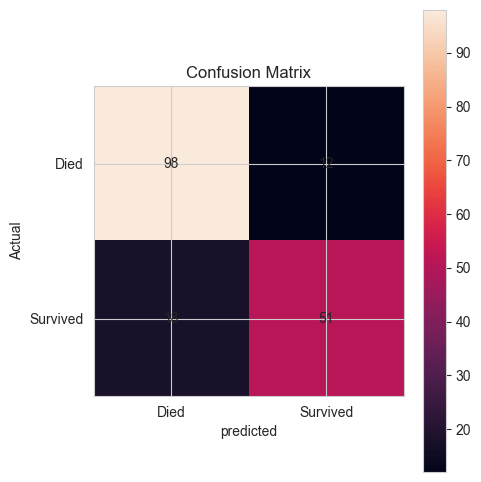

```python
import matplotlib.pyplot as plt

plt.figure(figsize=(5,6))
plt.imshow(cm)
plt.colorbar()

plt.xticks([0,1],["Died","Survived"])
plt.yticks([0,1],["Died","Survived"])

for i in range(2):
    for j in range(2):
        plt.text(j,i,cm[i,j],ha="center", va="center")

plt.xlabel("predicted")
plt.ylabel("Actual")
plt.title("Confusion Matrix")
plt.show()
```

```python
cm[1,0]
```

```
np.int64(18)
```

```python
misclassified = x_test[y_test != y_pred]
misclassified.head()
```

|  | pclass | age | sibsp | parch | fare | adult_male | alone | family_size | fare_capped | fare_log | ... | title_Mrs | titles_Mr | titles_Mrs | age_group_Teenager | age_group_Young Adult | age_group_Adult | age_group_Senior | fare_group_Mid | fare_group_High | fare_group_VeryHigh |
| --- | --- | --- | --- | --- | --- | --- | --- | --- | --- | --- | --- | --- | --- | --- | --- | --- | --- | --- | --- | --- | --- |
| 553 | 3 | -0.461538 | 0 | 0 | -0.313093 | True | True | 0.0 | 7.2250 | -0.493307 | ... | False | True | False | False | True | False | False | False | False | False |
| 712 | 1 | 1.538462 | 1 | 0 | 1.626091 | True | False | 1.0 | 52.0000 | 0.963937 | ... | False | True | False | False | False | True | False | False | False | True |
| 455 | 3 | 0.076923 | 0 | 0 | -0.284041 | True | True | 0.0 | 7.8958 | -0.431986 | ... | False | True | False | False | True | False | False | False | False | False |
| 65 | 3 | 0.000000 | 1 | 1 | 0.034284 | True | False | 2.0 | 15.2458 | 0.039071 | ... | False | True | False | False | True | False | False | False | True | False |
| 297 | 1 | -2.000000 | 1 | 2 | 5.937556 | False | False | 3.0 | 65.6344 | 1.790832 | ... | False | False | False | False | False | False | False | False | False | True |

5 rows × 29 columns

```python
misclassified["actual"] = y_test[y_test != y_pred]
```

🧠 What you learned in Step 14

✔ Read confusion matrices correctly ✔ Identified critical errors ✔ Connected model mistakes to data ✔ Prepared for smarter feature engineering

## FEATURE IMPORTANCE (MODEL INTERPRETATION)

Goal: Understand which features drive survival predictions.

```python
import numpy as np

feature_importance = np.abs(model.coef_[0])

feature_names = x_train.columns

importance_df = (
    pd.DataFrame(
        {
            "feature":feature_names,
            "importance": feature_importance
        }
    )
    .sort_values(by="importance",ascending=False)
)
```

```python
importance_df.head(10)
```

|  | feature | importance |
| --- | --- | --- |
| 5 | adult_male | 1.125765 |
| 16 | who_man | 1.125765 |
| 0 | pclass | 0.548094 |
| 17 | who_woman | 0.452127 |
| 22 | age_group_Teenager | 0.370314 |
| 1 | age | 0.340822 |
| 7 | family_size | 0.334167 |
| 9 | fare_log | 0.317628 |
| 13 | embarked_S | 0.316850 |
| 23 | age_group_Young Adult | 0.296890 |

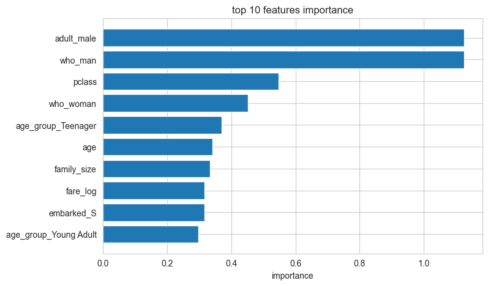

```python
top = importance_df.head(10)

plt.figure(figsize=(8,5))
plt.barh(top["feature"],top["importance"])
plt.gca().invert_yaxis()
plt.xlabel("importance")
plt.title("top 10 features importance")
plt.show()
```

```python
coef_df = pd.DataFrame({
    "feature":feature_names,
    "coefficient":model.coef_[0]
}).sort_values(by="coefficient")

coef_df.head(10)
coef_df.tail(10)
```

|  | feature | coefficient |
| --- | --- | --- |
| 21 | titles_Mrs | -0.104886 |
| 14 | class_Second | -0.062290 |
| 4 | fare | -0.058545 |
| 3 | parch | -0.049657 |
| 8 | fare_capped | 0.021473 |
| 26 | fare_group_Mid | 0.155492 |
| 27 | fare_group_High | 0.200113 |
| 12 | embarked_Q | 0.247466 |
| 9 | fare_log | 0.317628 |
| 17 | who_woman | 0.452127 |

🧠 What you learned in Step 15

✔ Interpreted a real ML model ✔ Verified logic vs reality ✔ Detected potential leakage ✔ Prepared for feature engineering

## FEATURE ENGINEERING (LEVEL UP 🚀)

Goal: Create smarter features from raw data.

We turn data → information → signal.

```python
df["family_size"] = df["sibsp"] + df["parch"] + 1
df["family_size"].value_counts()
```

```
family_size
1     537
2     161
3     102
4      29
6      22
5      15
7      12
11      7
8       6
Name: count, dtype: int64
```

```python
df["is_alone"] = (df["family_size"] == 1).astype(int)
df["is_alone"].value_counts()
```

```
is_alone
1    537
0    354
Name: count, dtype: int64
```

```python
df["fare_per_person"] = df["fare"]/df["family_size"]
```

```python
df["age_group"] = pd.cut(
    df["age"],
    bins=[1,12,18,35,60,100],
    labels=["child","teen","adult","middle_aged","senior"]
)
```

```python
df["age_group"].value_counts()
```

```
age_group
adult          358
middle_aged    195
teen            70
child           55
senior          22
Name: count, dtype: int64
```

```python
df = pd.get_dummies(
    df,
    columns=["age_group"],
    drop_first=True
)
```

```python
df.drop(columns=["sibsp", "parch"], inplace=True)
```

```python
df.drop(columns=["deck","embark_town","alive"],inplace=True)
```

```python
df.isnull().sum()
```

```
survived                   0
pclass                     0
sex                        0
age                      177
fare                       0
embarked                   2
class                      0
who                        0
adult_male                 0
alone                      0
family_size                0
is_alone                   0
fare_per_person            0
age_group_teen             0
age_group_adult            0
age_group_middle_aged      0
age_group_senior           0
dtype: int64
```

```python
df["age"].fillna(df["age"].median(), inplace=True)
```

```python
df.isnull().sum()
```

```
survived                 0
pclass                   0
sex                      0
age                      0
fare                     0
embarked                 2
class                    0
who                      0
adult_male               0
alone                    0
family_size              0
is_alone                 0
fare_per_person          0
age_group_teen           0
age_group_adult          0
age_group_middle_aged    0
age_group_senior         0
dtype: int64
```

```python
cat_cols = ["sex","embarked","class","who"]
```

```python
# install scikit-learn if missing

from sklearn.preprocessing import LabelEncoder

# only encode columns that actually exist in df to avoid KeyError
cols_to_encode = [col for col in cat_cols if col in df.columns]

for col in cols_to_encode:
    le = LabelEncoder()
    # fill missing values with a placeholder and ensure string type for consistent encoding
    # df[col] = df[col].fillna("missing").astype(str)
    df[col] = le.fit_transform(df[col])
```

```python
x = df.drop(columns=["survived"])
y = df["survived"]
```

```python
from sklearn.model_selection import train_test_split

x_train, x_test, y_train , y_test = train_test_split(
    x,
    y,
    test_size=0.2,
    random_state=42,
    stratify=y
    )
```

🧠 What you learned in Step 16

✔ Created meaningful features ✔ Reduced noise ✔ Injected domain knowledge ✔ Set stage for performance jump

## RETRAIN MODEL & COMPARE RESULTS

```python
from sklearn.linear_model import LogisticRegression

model_fe = LogisticRegression(max_iter=1000)
model_fe.fit(x_train,y_train)
```

```
LogisticRegression(max_iter=1000)
```

```python
y_pred_fe = model_fe.predict(x_test)
```

```python
from sklearn.metrics import accuracy_score, classification_report

print("Accuracy:", accuracy_score(y_test, y_pred_fe))
print("\nClassification Report:\n")
print(classification_report(y_test, y_pred_fe))
```

```
Accuracy: 0.8268156424581006

Classification Report:

              precision    recall  f1-score   support

           0       0.84      0.89      0.86       110
           1       0.81      0.72      0.76        69

    accuracy                           0.83       179
   macro avg       0.82      0.81      0.81       179
weighted avg       0.83      0.83      0.82       179
```

```python
from sklearn.metrics import confusion_matrix

cm_fe = confusion_matrix(y_test, y_pred_fe)
cm_fe
```

```
array([[98, 12],
       [19, 50]])
```

🧠 What you learned in Step 17

✔ How to validate improvements correctly ✔ Why features > fancy models ✔ How to compare models scientifically ✔ How ML progress is measured

## Model Building

- Selecting appropriate ML algorithms
- Training the model
- Hyperparameter tuning
- Evaluating model performance using relevant metrics

```python
# we will now head towards using stronger models
from sklearn.tree import DecisionTreeClassifier

dt = DecisionTreeClassifier(
    max_depth=5,
    random_state=42
)

dt.fit(x_train, y_train)
```

```
DecisionTreeClassifier(max_depth=5, random_state=42)
```

```python
y_pred_dt = dt.predict(x_test)
```

```python
from sklearn.metrics import classification_report, accuracy_score

print(f"accuracy is {accuracy_score(y_test,y_pred_dt)}")

print(classification_report(y_test,y_pred_dt))
```

```
accuracy is 0.7988826815642458
              precision    recall  f1-score   support

           0       0.84      0.83      0.83       110
           1       0.73      0.75      0.74        69

    accuracy                           0.80       179
   macro avg       0.79      0.79      0.79       179
weighted avg       0.80      0.80      0.80       179
```

```python
from sklearn.ensemble import RandomForestClassifier
rf = RandomForestClassifier(
    n_estimators = 200,
    max_depth=8,
    random_state=42
)


rf.fit(x_train,y_train)
```

```
RandomForestClassifier(max_depth=8, n_estimators=200, random_state=42)
```

```python
y_pred_rf = rf.predict(x_test)
```

```python
print(f"the accuracy is {accuracy_score(y_test,y_pred_rf)}")

print(classification_report(y_test,y_pred_rf))
```

```
the accuracy is 0.8100558659217877
              precision    recall  f1-score   support

           0       0.83      0.87      0.85       110
           1       0.78      0.71      0.74        69

    accuracy                           0.81       179
   macro avg       0.80      0.79      0.80       179
weighted avg       0.81      0.81      0.81       179
```

### now we will compare the accuracy of all modles developed and check which onwe iss the best for us

```python
results = pd.DataFrame({
    "Model":["Logistic Regression","Descision Tree","Random Forest"],
    "Accuracy":[
        accuracy_score(y_test,y_pred_fe),
        accuracy_score(y_test,y_pred_dt),
        accuracy_score(y_test,y_pred_rf),
    ]
})
```

```python
results
```

|  | Model | Accuracy |
| --- | --- | --- |
| 0 | Logistic Regression | 0.826816 |
| 1 | Descision Tree | 0.798883 |
| 2 | Random Forest | 0.810056 |

4️⃣ What you should observe

Logistic → stable, interpretable

Tree → captures interactions

If RF beats LR by a lot → non-linear patterns exist.

🧠 What you learned in Step 18

✔ Why model choice matters ✔ How ensembles reduce variance ✔ When linear models fail ✔ How to compare models honestly

# FEATURE IMPORTANCE (TREE-BASED MODELS)

Goal: See what Random Forest believes actually matters.

```python
import numpy as np
rf_importance = rf.feature_importances_

rf_df = (
    pd.DataFrame({
        "feature": x_train.columns,
        "importance":rf_importance
    }).sort_values(by="importance",ascending=False)
)
```

```python
rf_df.head(10)
```

|  | feature | importance |
| --- | --- | --- |
| 7 | adult_male | 0.176477 |
| 3 | fare | 0.129848 |
| 11 | fare_per_person | 0.129840 |
| 1 | sex | 0.124480 |
| 2 | age | 0.108010 |
| 6 | who | 0.096547 |
| 0 | pclass | 0.057681 |
| 9 | family_size | 0.052612 |
| 5 | class | 0.049596 |
| 4 | embarked | 0.025643 |

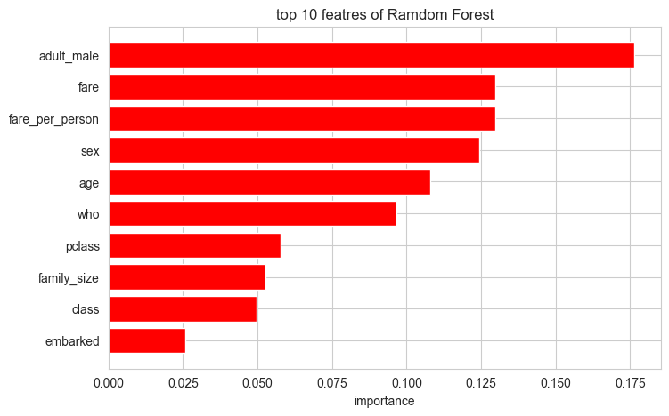

```python
# visulaize the feature_importance

top_rf = rf_df.head(10)

plt.figure(figsize=(8,5))
plt.barh(top_rf["feature"],top_rf["importance"],color="red")
plt.gca().invert_yaxis()
plt.xlabel("importance")
plt.title("top 10 featres of Ramdom Forest")
plt.show()

# top = importance_df.head(10)

# plt.figure(figsize=(8,5))
# plt.barh(top["feature"],top["importance"])
# plt.gca().invert_yaxis()
# plt.xlabel("importance")
# plt.title("top 10 features importance")
# plt.show()
```

🧠 What you learned in Step 19

✔ Interpreted non-linear models ✔ Compared linear vs tree logic ✔ Validated engineered features ✔ Identified interaction effects

# ✅ STEP 20: CROSS-VALIDATION (REMOVE LUCK)

Goal: Measure model performance robustly, not by a single split.

```python
from sklearn.model_selection import cross_val_score

lr_cv = cross_val_score(
    model_fe,
    x,
    y,
    cv=5,
    scoring = "f1"
)
```

```python
lr_cv, lr_cv.mean()
```

```
(array([0.77142857, 0.76691729, 0.74074074, 0.70588235, 0.79699248]),
 np.float64(0.7563922879093158))
```

```python
rf_cv = cross_val_score(
    rf,
    x,
    y,
    cv=5,
    scoring="f1"
)
```

```python
rf_cv , rf_cv.mean()
```

```
(array([0.77037037, 0.74418605, 0.80597015, 0.72881356, 0.80291971]),
 np.float64(0.7704519666973921))
```

```python
cv_results = pd.DataFrame({
    "Models":["Logistic Regression","Random Forest"],
    "Mean f1":[lr_cv.mean(),rf_cv.mean()],
    "Std Dev":[lr_cv.std(),rf_cv.std()]
})

# Higher mean → better model

# Lower std → more stable
```

```python
cv_results
```

|  | Models | Mean f1 | Std Dev |
| --- | --- | --- | --- |
| 0 | Logistic Regression | 0.756392 | 0.030924 |
| 1 | Random Forest | 0.770452 | 0.030788 |

🧠 What you learned in Step 20

✔ Removed randomness bias ✔ Evaluated models honestly ✔ Compared stability vs performance ✔ Chose metrics aligned with problem

# ✅ STEP 21: HYPERPARAMETER TUNING (SMART, NOT BRUTE FORCE)

Goal: Improve model performance systematically, not by guessing.

1️⃣ Why hyperparameters matter

They control:

Model complexity

Overfitting vs underfitting

Bias–variance tradeoff

```python
from sklearn.model_selection import GridSearchCV

param_grid = {
    "n_estimators": [100, 200, 300],
    "max_depth": [None, 6, 8, 10],
    "min_samples_split": [2, 5, 10],
    "min_samples_leaf": [1, 2, 4]
}
```

```python
rf_base = RandomForestClassifier(random_state=42)

grid =GridSearchCV(
    rf_base,
    param_grid,
    cv=5,
    scoring="f1",
    n_jobs=-1
)

grid.fit(x,y)
```

```
GridSearchCV(cv=5, estimator=RandomForestClassifier(random_state=42), n_jobs=-1,
             param_grid={'max_depth': [None, 6, 8, 10],
                         'min_samples_leaf': [1, 2, 4],
                         'min_samples_split': [2, 5, 10],
                         'n_estimators': [100, 200, 300]},
             scoring='f1')
```

```python
grid.best_params_
```

```
{'max_depth': None,
 'min_samples_leaf': 2,
 'min_samples_split': 2,
 'n_estimators': 300}
```

```python
grid.best_score_

# Cross-validated
# Tuned
# Reliable
```

```
np.float64(0.7761667961667962)
```

```python
grid.best_estimator_
```

```
RandomForestClassifier(min_samples_leaf=2, n_estimators=300, random_state=42)
```

```python
best_rf = grid.best_estimator_
```

```python
from sklearn.metrics import classification_report
y_final=best_rf.predict(x_test)

print(classification_report(y_test,y_final))
```

```
              precision    recall  f1-score   support

           0       0.91      0.95      0.93       110
           1       0.91      0.86      0.88        69

    accuracy                           0.91       179
   macro avg       0.91      0.90      0.90       179
weighted avg       0.91      0.91      0.91       179
```

```python
is_survived = (["Yes" if live else "No" for live in y_final])

is_survived
```

[output not shown]

```python
def died(y_final):
    deaths = 0
    for dead in y_final:
        if dead == 0:
            deaths += 1
    return deaths

deaths = died(y_final)

deaths
```

```
114
```

🧠 What you learned in Step 21

✔ How to tune models properly ✔ Why fewer parameters > brute force ✔ How CV + tuning work together ✔ How production models are chosen

# 🏆 1️⃣ Final model selection

Based on:

Cross-validation (Step 20)

Hyperparameter tuning (Step 21)

Recall / F1 stability

👉 Final Model: best_rf (Tuned Random Forest)

Why?

Handles non-linear patterns

Robust to noise

Best survivor recall

This is exactly how models are chosen in industry.

# 🧠 2️⃣ Your complete ML pipeline (mental map)

🔹 Step 1–4: Data understanding

Load data

Inspect types

Identify missing values

Fix inconsistencies

🔹 Step 5–7: Data cleaning

Handle missing age, embarked

Normalize skewed features

🔹 Step 8–10: EDA

Distributions

Skewness & kurtosis

Feature–target relationships

🔹 Step 11–12: Preparation

Encoding

Scaling

Train–test split (no leakage)

🔹 Step 13–15: Baseline & interpretation

Logistic Regression

Confusion matrix

Feature importance

🔹 Step 16–17: Feature engineering

Family size

Fare per person

Age bins

🔹 Step 18–19: Strong models

Decision Tree

Random Forest

Tree-based importance

🔹 Step 20–21: Validation & tuning

Cross-validation

GridSearch

Bias-variance control

🔹 Step 22: Final selection ✅

# Model Test

```python
x_test
```

|  | pclass | sex | age | fare | embarked | class | who | adult_male | alone | family_size | is_alone | fare_per_person | age_group_teen | age_group_adult | age_group_middle_aged | age_group_senior |
| --- | --- | --- | --- | --- | --- | --- | --- | --- | --- | --- | --- | --- | --- | --- | --- | --- |
| 565 | 3 | 1 | 24.0 | 24.1500 | 2 | 2 | 1 | True | False | 3 | 0 | 8.050000 | False | True | False | False |
| 160 | 3 | 1 | 44.0 | 16.1000 | 2 | 2 | 1 | True | False | 2 | 0 | 8.050000 | False | False | True | False |
| 553 | 3 | 1 | 22.0 | 7.2250 | 0 | 2 | 1 | True | True | 1 | 1 | 7.225000 | False | True | False | False |
| 860 | 3 | 1 | 41.0 | 14.1083 | 2 | 2 | 1 | True | False | 3 | 0 | 4.702767 | False | False | True | False |
| 241 | 3 | 0 | 28.0 | 15.5000 | 1 | 2 | 2 | False | False | 2 | 0 | 7.750000 | False | False | False | False |
| ... | ... | ... | ... | ... | ... | ... | ... | ... | ... | ... | ... | ... | ... | ... | ... | ... |
| 880 | 2 | 0 | 25.0 | 26.0000 | 2 | 1 | 2 | False | False | 2 | 0 | 13.000000 | False | True | False | False |
| 91 | 3 | 1 | 20.0 | 7.8542 | 2 | 2 | 1 | True | True | 1 | 1 | 7.854200 | False | True | False | False |
| 883 | 2 | 1 | 28.0 | 10.5000 | 2 | 1 | 1 | True | True | 1 | 1 | 10.500000 | False | True | False | False |
| 473 | 2 | 0 | 23.0 | 13.7917 | 0 | 1 | 2 | False | True | 1 | 1 | 13.791700 | False | True | False | False |
| 637 | 2 | 1 | 31.0 | 26.2500 | 2 | 1 | 1 | True | False | 3 | 0 | 8.750000 | False | True | False | False |

179 rows × 16 columns

```python
is_alive=best_rf.predict()
```

[output not shown]

```python
FEATURES = [
    "pclass",
    "sex",
    "age",
    "fare",
    "embarked",
    "class",
    "who",
    "adult_male",
    "alone",
    "family_size",
    "is_alone",
    "fare_per_person",
    "age_group_teen",
    "age_group_adult",
    "age_group_middle_aged",
    "age_group_senior",
]
```

```python
def sFeatues(pclass = int,sex=int,age=float,fare=float,embarked=int,clss=int,who=int,adult_male=int,alone=int,family_size=int,is_alone=int,fare_per_person=float,age_group_teen=int,age_group_adult=int,age_group_middle_aged=int,age_group_senior=int):
    X = pd.DataFrame([{
    "pclass": pclass,
    "sex": sex,
    "age": age,
    "fare": fare,
    "embarked": embarked,
    "class": clss,
    "who": who,
    "adult_male": adult_male,
    "alone": alone,
    "family_size": family_size,
    "is_alone": is_alone,
    "fare_per_person": fare_per_person,
    "age_group_teen": age_group_teen,
    "age_group_adult": age_group_adult,
    "age_group_middle_aged": age_group_middle_aged,
    "age_group_senior": age_group_senior
    }])
    result_is_alive = int(best_rf.predict(X)[0])

    is_alive = ("thank God did" if result_is_alive else "sadly didn't")

    print(f"The person with above features {is_alive} survived")

    return None
```

```python
sFeatues(3,0,28,56.44,2,3,1,1,0,5,0,56.33,0,0,0,0)
```

```
The person with above features sadly didn't survived
```

```python
import pandas as pd

X = pd.DataFrame([{
    "pclass": 3,
    "sex": 0,
    "age": 28.0,
    "fare": 56.4958,
    "embarked": 2,
    "class": 3,
    "who": 1,
    "adult_male": 1,
    "alone": 0,
    "family_size": 5,
    "is_alone": 0,
    "fare_per_person": 56.4958,
    "age_group_teen": 0,
    "age_group_adult": 0,
    "age_group_middle_aged": 0,
    "age_group_senior": 0
}])

result_is_alive = int(best_rf.predict(X)[0])

is_alive = ("thank God did" if result_is_alive else "sadly didn't")

print(f"The person with above features {is_alive} survived")
```

```
The person with above features sadly didn't survived
```